# Read before doing anything

We found an error in the training dataset 2 (there was a whitespace in front of each feature name). Therefore we preprocessed and fixed it. Our files have been renamed and they are as follows:

- ./data/trn_set_1.csv --> BATADAL_dataset03.csv
- ./data/trn_set_2.csv --> BATADAL_dataset04.csv
- ./data/test_set.csv --> BATADAL_test_dataset.csv

# PCA task

```python
from sklearn.decomposition import PCA
import pandas as pd
from sklearn import preprocessing
import matplotlib.pyplot as plt
import numpy as np
import seaborn as sns
sns.set()
```

We are using the training set 1 because it only contains normal behavior

```python
file_name = "trn_set_1"
DATA_PATH = r"C:../data/{}.csv".format(file_name)

data_trn_1 = pd.read_csv(DATA_PATH, header=0, parse_dates=['DATETIME'], index_col='DATETIME', dayfirst=True)
data_trn_1.index = pd.DatetimeIndex(data_trn_1.index.values, freq = data_trn_1.index.inferred_freq)

discrete_variables = [f'S_PU{num+1}' for num in range(11)] + ['S_V2']

# drop discrete variables
data_trn_1 = data_trn_1.drop(columns=discrete_variables)
data_trn_1 = data_trn_1.drop(columns='ATT_FLAG') # labels are useless for first dataset
```

First of all... NORMALIZATION!

```python
df_mean_trn = data_trn_1.mean()
df_std_trn = data_trn_1.std()
normalized_df=(data_trn_1-df_mean_trn)/df_std_trn
# display(normalized_df.head())

# remove columns with NaN (they had only the same value --> not possible to normalize them)
print(normalized_df.columns[normalized_df.isna().any()].tolist())
# spoiler: we will need to remove these columns also from the testset when we will do anomaly detection


normalized_df.dropna(axis='columns', inplace=True)
# normalized_df.head()
```

```
['F_PU3', 'F_PU5', 'F_PU9']
```

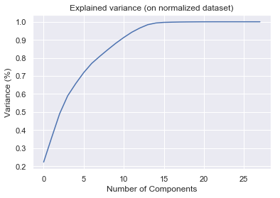

```python
n_of_components = normalized_df.shape[1]
pca_full = PCA(n_of_components).fit(normalized_df)

plt.figure()
plt.plot(np.cumsum(pca_full.explained_variance_ratio_))
plt.xlabel('Number of Components')
plt.ylabel('Variance (%)')
plt.title('Explained variance (on normalized dataset)')
plt.show()
```

Let's create a function that retrieves the number of principal components that we need if we want to capture a certain percentage of variance in the data

```python
def get_num_of_principal_components(fitted_pca, desired_variance_perc):
    cumulative_variance = np.cumsum(fitted_pca.explained_variance_ratio_)
    return [i for i in range(len(cumulative_variance)) if cumulative_variance[i] > desired_variance_perc/100][0]
```

Let's use this number of components to project the data into a lower dimensional feature space. In order to capture the normal behaviour (and therefore being able to detect anomalies) we need to capture enough variance of the data, but not too much. Otherwise we would also learn about the anomalies. This is actually the power of PCA!

```python
var_perc_to_capture = 99  # variance that we want to capture to learn the normal behavior

n = get_num_of_principal_components(pca_full, var_perc_to_capture)
print(f"{n} components out of {normalized_df.shape[1]} will be used to project into the normal space")

pca_normal = PCA(n_components=n).fit(normalized_df)
```

```
14 components out of 28 will be used to project into the normal space
```

# Training set 2

We will use it to tune the threshold on the residuals, obtained with the PCA projection learned on the normal dataset (training set 1)

```python
file_name = "trn_set_2"
DATA_PATH = r"C:../data/{}.csv".format(file_name)

data_trn_2 = pd.read_csv(DATA_PATH, header=0, parse_dates=['DATETIME'], index_col='DATETIME', dayfirst=True)
data_trn_2.index = pd.DatetimeIndex(data_trn_2.index.values, freq = data_trn_2.index.inferred_freq)

labels = data_trn_2['ATT_FLAG'].map({-999:0, 1:1})

# normalize using mean and standard deviation from the training set (https://www.researchgate.net/post/If_I_used_data_normalization_x-meanx_stdx_for_training_data_would_I_use_train_Mean_and_Standard_Deviation_to_normalize_test_data)
data_trn_2 = (data_trn_2-df_mean_trn)/df_std_trn

# remove also features which could not be normalized when training PCA on the 'normal' dataset
data_trn_2 = data_trn_2[list(normalized_df.columns)]
data_trn_2.head()
```

|  | L_T1 | L_T2 | L_T3 | L_T4 | L_T5 | L_T6 | L_T7 | F_PU1 | F_PU2 | F_PU4 | ... | P_J300 | P_J256 | P_J289 | P_J415 | P_J302 | P_J306 | P_J307 | P_J317 | P_J14 | P_J422 |
| --- | --- | --- | --- | --- | --- | --- | --- | --- | --- | --- | --- | --- | --- | --- | --- | --- | --- | --- | --- | --- | --- |
| 2016-07-04 00:00:00 | -0.196938 | 1.330672 | -1.491337 | 0.985575 | 0.152068 | 0.730101 | 1.311853 | -0.726073 | 0.572580 | -0.854028 | ... | 0.180078 | -1.112168 | 0.162997 | 0.417488 | -0.625850 | 0.828220 | -0.626887 | 0.764555 | 1.316906 | 0.070250 |
| 2016-07-04 01:00:00 | -0.014053 | 0.847225 | -1.476598 | 1.133818 | 0.736973 | 0.391996 | 1.480762 | -1.146031 | 0.472674 | 1.156207 | ... | -1.231942 | 0.983100 | -1.222884 | 0.284207 | 1.212881 | 1.219223 | 1.227468 | -1.533787 | 1.987870 | -1.242695 |
| 2016-07-04 02:00:00 | 0.360030 | 0.254833 | -0.798597 | 1.189409 | 1.525915 | -1.242181 | -0.099743 | -1.099259 | 0.483565 | 1.080515 | ... | -1.432617 | 1.167455 | -1.425068 | 0.582756 | 1.221939 | 1.321485 | 1.236480 | -1.770575 | 1.947707 | -1.464655 |
| 2016-07-04 03:00:00 | 0.783991 | -0.167332 | -0.046901 | 0.874393 | 1.104239 | -2.200147 | -1.089066 | -1.276398 | 0.441661 | 1.098118 | ... | -0.279649 | 1.485350 | -0.248723 | -1.864285 | 1.618217 | -1.023529 | 1.601493 | 0.822812 | 2.240663 | -0.403765 |
| 2016-07-04 04:00:00 | 1.166388 | -0.412460 | 0.778492 | -0.682155 | 0.492129 | 0.110241 | 0.189815 | -1.384870 | 0.415856 | 1.081688 | ... | -0.400054 | 1.500713 | -0.373710 | -1.865618 | 1.776729 | -1.025534 | 1.759214 | 0.866035 | 2.420216 | -0.531674 |

5 rows × 28 columns

```python
# we are going to use the pca that we obtained in the training set to see if we can detect anomalies in the test set
data_trn_2_pca = pd.DataFrame(pca_normal.transform(data_trn_2), data_trn_2.index)
data_trn_2_pca.head()
```

|  | 0 | 1 | 2 | 3 | 4 | 5 | 6 | 7 | 8 | 9 | 10 | 11 | 12 | 13 |
| --- | --- | --- | --- | --- | --- | --- | --- | --- | --- | --- | --- | --- | --- | --- |
| 2016-07-04 00:00:00 | 0.075747 | -1.759064 | 1.046464 | -2.202636 | 1.165778 | -1.268557 | -1.466525 | -0.782691 | -0.494567 | 0.307092 | 1.561447 | 0.161223 | -0.087134 | 0.276678 |
| 2016-07-04 01:00:00 | -0.397771 | 0.841297 | 3.719561 | -1.604692 | -1.098592 | 2.030955 | -2.077623 | -1.670782 | -0.537386 | 0.491057 | 1.423361 | 1.279653 | -0.051091 | 0.611376 |
| 2016-07-04 02:00:00 | -0.658484 | 1.348219 | 3.871629 | -1.683914 | -2.228514 | 2.496163 | -0.496192 | -0.336196 | -0.684132 | 0.155262 | 1.892323 | 0.761520 | 0.097508 | 0.154468 |
| 2016-07-04 03:00:00 | 1.584379 | 2.320175 | 3.274445 | -0.595629 | 2.158951 | 1.899796 | 3.180843 | 0.721987 | -0.092838 | -0.394144 | 0.898381 | 0.677904 | 0.312734 | -0.237234 |
| 2016-07-04 04:00:00 | 1.303175 | 2.504393 | 3.687824 | 0.033572 | 3.167747 | 1.685582 | 1.184316 | 0.065902 | 0.651978 | -0.097412 | -0.605048 | -0.054247 | 0.429401 | -0.646805 |

```python
# reconstruct dataframe
data_trn_2_reconstr = pd.DataFrame(pca_normal.inverse_transform(data_trn_2_pca), data_trn_2_pca.index)
data_trn_2_reconstr.columns = data_trn_2.columns
data_trn_2_reconstr.head()
```

|  | L_T1 | L_T2 | L_T3 | L_T4 | L_T5 | L_T6 | L_T7 | F_PU1 | F_PU2 | F_PU4 | ... | P_J300 | P_J256 | P_J289 | P_J415 | P_J302 | P_J306 | P_J307 | P_J317 | P_J14 | P_J422 |
| --- | --- | --- | --- | --- | --- | --- | --- | --- | --- | --- | --- | --- | --- | --- | --- | --- | --- | --- | --- | --- | --- |
| 2016-07-04 00:00:00 | -0.106904 | 1.514695 | -1.311594 | 1.017071 | 0.163201 | 0.989949 | 1.138068 | -0.578881 | 0.429139 | -0.872120 | ... | 0.140846 | -1.151963 | 0.123192 | 0.363950 | -0.587454 | 0.817990 | -0.589617 | 0.521913 | 1.377750 | 0.016845 |
| 2016-07-04 01:00:00 | 0.302313 | 0.812560 | -1.243958 | 1.149800 | 0.781887 | 0.546121 | 1.469509 | -0.986505 | 0.522458 | 1.199490 | ... | -1.159709 | 1.021928 | -1.147627 | 0.346504 | 0.847683 | 0.848056 | 0.864286 | -1.926305 | 2.000428 | -1.186529 |
| 2016-07-04 02:00:00 | 0.633864 | 0.300736 | -0.529509 | 1.218895 | 1.573529 | -1.067316 | -0.125225 | -1.006312 | 0.468520 | 1.172103 | ... | -1.400503 | 1.127872 | -1.391160 | 0.493005 | 0.892204 | 0.961142 | 0.907770 | -2.187861 | 1.967487 | -1.426313 |
| 2016-07-04 03:00:00 | 1.065512 | 0.284762 | 0.359425 | 0.959920 | 1.135725 | -1.606893 | -1.551861 | -1.133498 | 0.471685 | 1.120153 | ... | -0.395834 | 1.317944 | -0.366254 | -2.125991 | 1.495178 | -1.174654 | 1.481176 | 0.505860 | 2.101088 | -0.466888 |
| 2016-07-04 04:00:00 | 1.343338 | -0.051320 | 0.884304 | -0.660797 | 0.511718 | 0.049649 | 0.209504 | -1.239234 | 0.508821 | 1.084027 | ... | -0.587184 | 1.359142 | -0.560114 | -2.193066 | 1.662875 | -1.156999 | 1.649986 | 0.980613 | 2.142919 | -0.660677 |

5 rows × 28 columns

```python
# Now, we compute the residuals: original normalized data - reconstructed data
residual_trn_2 = data_trn_2.subtract(data_trn_2_reconstr)
squared_res_trn_2 = pd.DataFrame(np.power(residual_trn_2, 2), residual_trn_2.index)
squared_sum_res_trn_2 = squared_res_trn_2.sum(axis=1)
```

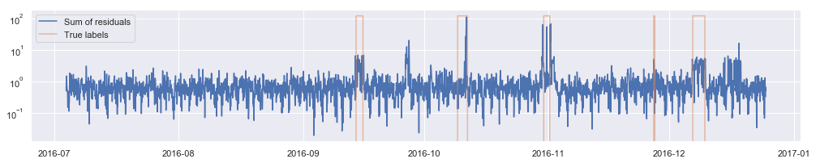

```python
# Let's visualize it!

att_true = int(np.max(squared_sum_res_trn_2) + 10)
att_false = int(np.min(squared_sum_res_trn_2) - 10)
labels_remap = labels.map({0:att_false, 1:att_true})

plt.figure(figsize=(17,3))
plt.plot(squared_sum_res_trn_2, label='Sum of residuals')
plt.plot(labels_remap, label="True labels", alpha=0.5)
plt.legend()
plt.yscale("log")
plt.show()
```

It is clear that the PCA learned on the normal behaviour, is not able to reconstruct anomalies, and we can therefore find them by plotting the sum of the squared residuals. Results look really promising! Let's now do some gridsearch to find a treshold on the residuals.

Some of the attacks can be clearly found using the residuals. Also, it seems there are some attacks which are not labeled (on https://batadal.net/data.html they say "This dataset with partially labeled data was released on November 28 2016. The dataset is around 6 months long and contains several attacks, some of which are approximately labeled")

# Grid Search

Let's have a look at the eigenvalues we have

```python
print(f"{n} components used to capture normal behaviour: ")
normal_eigvals = pca_full.explained_variance_[:n]
print(normal_eigvals)

print(f"\n\n{normalized_df.shape[1] - n} components used to capture anomalies:")
abnormal_eigvals = pca_full.explained_variance_[n:]
print(abnormal_eigvals)
```

```
14 components used to capture normal behaviour:
[6.24235462 3.8029054  3.7134553  2.7617425  1.88823779 1.70893114
 1.43106363 1.08940895 1.03238909 0.99527794 0.89818362 0.81535579
 0.65018177 0.52191212]


14 components used to capture anomalies:
[2.60905677e-01 9.72200192e-02 3.29941779e-02 2.45361512e-02
 1.35882569e-02 8.55931596e-03 7.43847442e-03 1.67935446e-03
 1.42828291e-03 1.86707428e-04 6.25413551e-05 1.24836988e-06
 1.17793689e-07 1.47452523e-08]
```

We need to compute a threshold for the residual error, as explained in the paper about PCA. (Diagnosing Network-wide traffic anomalies)

```python
def get_conf_mat_entry(results, true_attack, pred_attack):
    # just a helper function to retrieve entries of the confusion matrix
    result = results[
        (results['true'] == (1 if true_attack else 0))
        &
        (results['pred'] == (1 if pred_attack else 0))
    ]
    result.head()
    return result.shape[0]
```

```python
c_values = np.linspace(1, 10, 100)
```

We go from 1 to 10, as possible values. We tune this value with using GridSearch, on the F0.25 score. This is done because we are interested in high precision, so that we lower the number of false positives.

```
Best threshold: 2.7035559717308173
Best c_alpha: 2.6363636363636367
TP: 83. FP:98. TN:3860. FN: 136
Prec: 0.4585635359116022, Rec: 0.3789954337899543
Best Fbeta: 0.4529695024077046
```

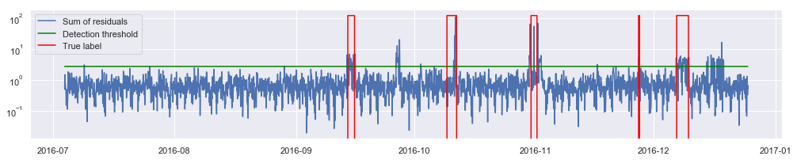

```
Detection results
```

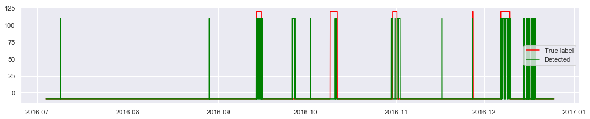

```python
r = n # number of normal components for us

phi_1 = np.sum(abnormal_eigvals)
phi_2 = np.sum(np.power(abnormal_eigvals, 2))
phi_3 = np.sum(np.power(abnormal_eigvals, 3))

h_0 = (2 * phi_1 * phi_3) / (3 * phi_2**2)
h_0 = 1 - h_0

# f0.25 as evaluation metric, so that we reduce the number of false positives
beta = 0.25
fbeta_best = -1
c_best = -1
threshold_best = -1
best_t_p = -1
best_f_p = -1
best_t_n = -1
best_f_n = -1
best_prec = -1
best_rec = -1
for c_val in c_values:

    # c_alpha is a hyperparameter, let's optimize it!
    c_alpha = c_val

    # multiple steps to make it understandable
    delta_alpha_squared = 0
    delta_alpha_squared += c_alpha * np.sqrt(2 * phi_2 * h_0**2) / phi_1
    delta_alpha_squared += 1
    delta_alpha_squared += phi_2 * h_0 * (h_0 - 1) / (phi_1**2)
    delta_alpha_squared **= (1/h_0)
    delta_alpha_squared *= phi_1

    detection = squared_sum_res_trn_2 > delta_alpha_squared
    detection = detection.astype(int)

    res = pd.concat([labels[detection.index], detection], axis=1) # only take labels when predicted
    res.columns = ['true', 'pred']
    res.set_index(detection.index)

    t_p = get_conf_mat_entry(res, true_attack=True, pred_attack=True)
    t_n = get_conf_mat_entry(res, true_attack=False, pred_attack=False)
    f_p = get_conf_mat_entry(res, true_attack=False, pred_attack=True)
    f_n = get_conf_mat_entry(res, true_attack=True, pred_attack=False)

    try:
        precision = t_p/(t_p + f_p)
    except:
        continue

    try:
        recall = t_p/(t_p + f_n)
    except:
        continue

    if (precision + recall ) == 0:
        continue

    fbeta = ( 1 + (beta**2)) * ( precision * recall ) / ((beta**2) * precision + recall )

    if fbeta > fbeta_best:
        # save all the parameters for the best fbeta score
        fbeta_best = fbeta
        threshold_best = delta_alpha_squared
        c_best = c_alpha
        best_t_p = t_p
        best_f_p = f_p
        best_t_n = t_n
        best_f_n = f_n
        best_prec = precision
        best_rec = recall



print(f"Best threshold: {threshold_best}")
print(f"Best c_alpha: {c_best}")
print(f"TP: {best_t_p}. FP:{best_f_p}. TN:{best_t_n}. FN: {best_f_n}")
print(f"Prec: {best_prec}, Rec: {best_rec}")
print(f"Best Fbeta: {fbeta_best}")

detection = squared_sum_res_trn_2 > threshold_best
detection = detection.astype(int)

threshold_series = pd.DataFrame(np.array([threshold_best for i in range(detection.shape[0])]), detection.index)
plt.figure(figsize=(17,3))
plt.plot(squared_sum_res_trn_2, label='Sum of residuals')
plt.plot(threshold_series, label='Detection threshold', color='green')
plt.plot(labels_remap, color='red', label='True label')
plt.legend()
plt.yscale("log")
plt.show()

print("Detection results")
plt.figure(figsize=(17,3))
plt.plot(labels_remap, color='red', label='True label')
plt.plot(detection.map({0:att_false, 1:att_true-10}), color='green', label='Detected')
plt.legend()
plt.show()
```

How good was our detection?

```python
print(f"{best_f_p} false positives out of {best_t_p + best_f_p} attacks detected. ({best_t_p + best_f_n} attacks were labeled) --> {best_t_p} attacks correctly detected!")
```

```
98 false positives out of 181 attacks detected. (219 attacks were labeled) --> 83 attacks correctly detected!
```

It is said that the dataset is partially labeled, so maybe our false positives are not that false, afterall. Actually, by looking at the image about attacks on the BATADAL website, almost the totality of these detected attacks are real attacks!

## Investigation on the type of anomalies that we can detect with PCA

We will now investigate the True Positives, to understand what we are able to detect with using PCA

```python
detection = squared_sum_res_trn_2 > threshold_best
detection = detection.astype(int)

res = pd.concat([labels[detection.index], detection], axis=1) # only take labels when predicted
res.columns = ['true', 'pred']
res.set_index(detection.index, inplace=True)

detected = res[(res['true'] == 1) & (res['pred'] == 1)]
print(detected.index[0])
print(detected.index[-1])
```

```
2016-09-14 03:00:00
2016-12-09 21:00:00
```

All detected anomalies are from September 2016 to the end of the data (end of 2016). Therefore, we focus only on this slice of data

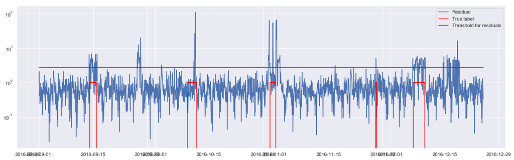

```python
start = '2016-09'
end = '2016-12-29'

plt.figure(figsize=(20,6))
plt.plot(squared_sum_res_trn_2.loc[start:end], label='Residual')
plt.plot(labels.loc[start:end], color='red', label='True label')
plt.plot(threshold_series.loc[start:end], color='green', label='Threshold for residuals')
plt.legend()
plt.yscale("log")
plt.show()
```

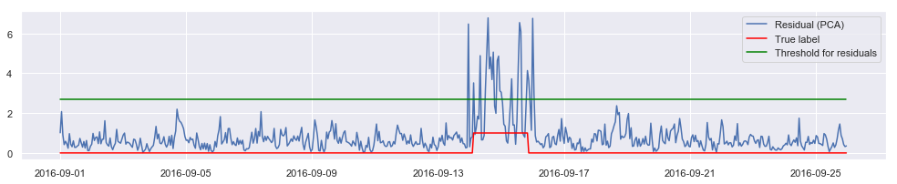

```python
start = '2016-09-01'
end = '2016-09-25'
cols_plot = ['L_T7', 'F_PU10', 'F_PU11']


plt.figure(figsize=(17,3))
plt.plot(squared_sum_res_trn_2.loc[start:end], label='Residual (PCA)')
plt.plot(labels.loc[start:end], color='red', label='True label')
threshold_series = pd.DataFrame(np.array([threshold_best for i in range(detection.shape[0])]), detection.index)
plt.plot(threshold_series.loc[start:end], color='green', label='Threshold for residuals')
plt.legend()
plt.show()
```

Let's see what kind of shape this anomaly has, by looking at the original signals

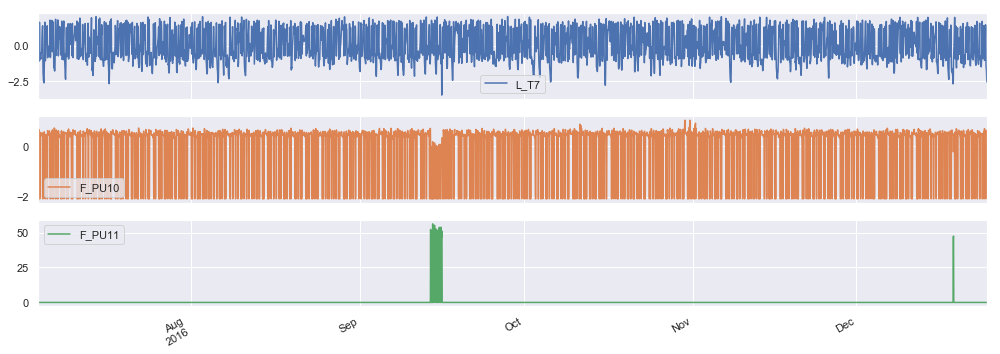

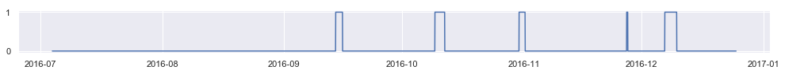

```python
data_trn_2[cols_plot].plot(subplots=True, figsize=(17,2*len(cols_plot)))
plt.show()

plt.figure(figsize=(17,1))
plt.plot(labels)
plt.show()
```

This is definitely a **point anomaly**: the level of water reached by 'L_T7' is the lowest across the whole timeseries. Therefore, it does not depend on any context, and it is anomalous by itself.

Let's now move to the second detected anomaly: December 2016

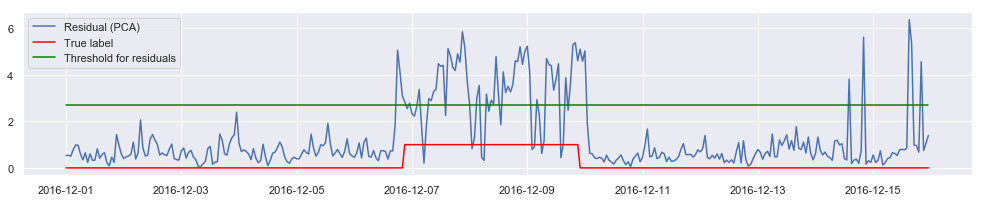

```python
start = '2016-12-01'
end = '2016-12-15'
cols_plot = ['L_T4', 'F_PU7']



plt.figure(figsize=(17,3))
plt.plot(squared_sum_res_trn_2.loc[start:end], label='Residual (PCA)')
plt.plot(labels.loc[start:end], color='red', label='True label')
threshold_series = pd.DataFrame(np.array([threshold_best for i in range(detection.shape[0])]), detection.index)
plt.plot(threshold_series.loc[start:end], color='green', label='Threshold for residuals')
plt.legend()
plt.show()
```

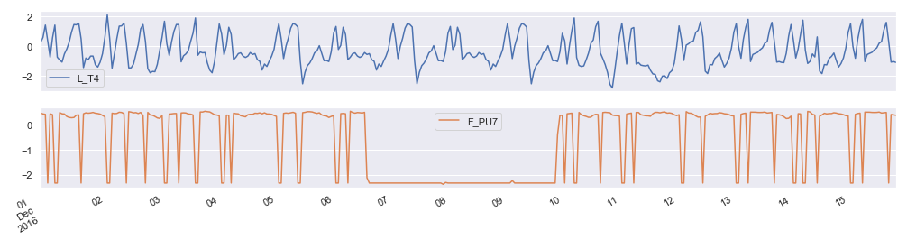

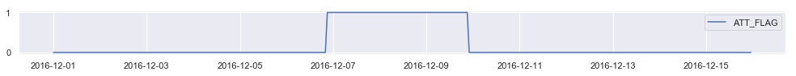

```python
data_trn_2[cols_plot].loc[start:end].plot(subplots=True, figsize=(17,2*len(cols_plot)))
plt.show()

plt.figure(figsize=(17,1))
plt.plot(labels.loc[start:end])
plt.legend()
plt.show()
```

This is a **collective anomaly**, because F_PU7 can take on this low value without it being an anomaly. The problem is when these values occur together as a collection. As explained in the anomaly taxonomy in the anomaly detection survey paper: **The individual data instances in a collective anomaly may not be anomalies by themselves, but their occurrence together as a collection is anomalous**

Now, let's look at one anomaly which has been detected by PCA, but not fully nor in a satisfying amount. This is the anomaly happened around the 10th of October 2016, and interested 'L_T1' and other signals (please, see the label data on batadal website)

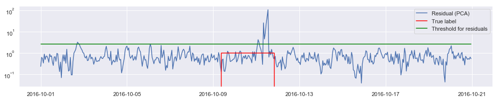

```python
start = '2016-10-01'
end = '2016-10-20'
cols_plot = ['L_T1', 'F_PU1', 'F_PU2']



plt.figure(figsize=(17,3))
plt.plot(squared_sum_res_trn_2.loc[start:end], label='Residual (PCA)')
plt.plot(labels.loc[start:end], color='red', label='True label')
threshold_series = pd.DataFrame(np.array([threshold_best for i in range(detection.shape[0])]), detection.index)
plt.plot(threshold_series.loc[start:end], color='green', label='Threshold for residuals')
plt.legend()
plt.yscale("log")
plt.show()
```

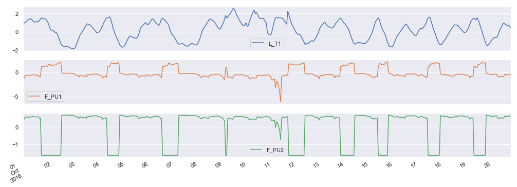

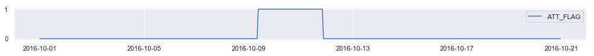

```python
# real original data
data_trn_2[cols_plot].loc[start:end].plot(subplots=True, figsize=(17,2*len(cols_plot)))
plt.show()

plt.figure(figsize=(17,1))
plt.plot(labels.loc[start:end])
plt.legend()
plt.show()
```

# Testing on the test set

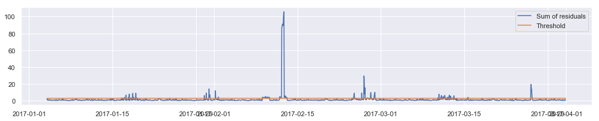

```python
file_name = "test_set"
DATA_PATH = r"C:../data/{}.csv".format(file_name)

data_test = pd.read_csv(DATA_PATH, header=0, parse_dates=['DATETIME'], index_col='DATETIME', dayfirst=True)
data_test.index = pd.DatetimeIndex(data_test.index.values, freq = data_test.index.inferred_freq)

# normalize using mean and standard deviation from the training set (https://www.researchgate.net/post/If_I_used_data_normalization_x-meanx_stdx_for_training_data_would_I_use_train_Mean_and_Standard_Deviation_to_normalize_test_data)
data_test = (data_test-df_mean_trn)/df_std_trn

# remove also features which could not be normalized when training PCA on the 'normal' dataset
data_test = data_test[list(normalized_df.columns)]


# we are going to use the pca that we obtained in the training set to see if we can detect anomalies in the test set
df_test_pca = pd.DataFrame(pca_normal.transform(data_test), data_test.index)

# reconstruct dataframe
df_test_reconstructed = pd.DataFrame(pca_normal.inverse_transform(df_test_pca), df_test_pca.index)
df_test_reconstructed.columns = data_test.columns

# Now, we compute the residuals: original normalized data - reconstructed data
residual_test_df = data_test.subtract(df_test_reconstructed)
squared_res_test_df = pd.DataFrame(np.power(residual_test_df, 2), residual_test_df.index)
squared_sum_test_res = squared_res_test_df.sum(axis=1)

# threshold tuned on the training
threshold = pd.DataFrame(np.array([threshold_best for i in range(squared_sum_test_res.shape[0])]), squared_sum_test_res.index)

# visualize!
plt.figure(figsize=(17,3))
plt.plot(squared_sum_test_res, label='Sum of residuals')
plt.plot(threshold, label='Threshold')
plt.legend()
plt.show()
```

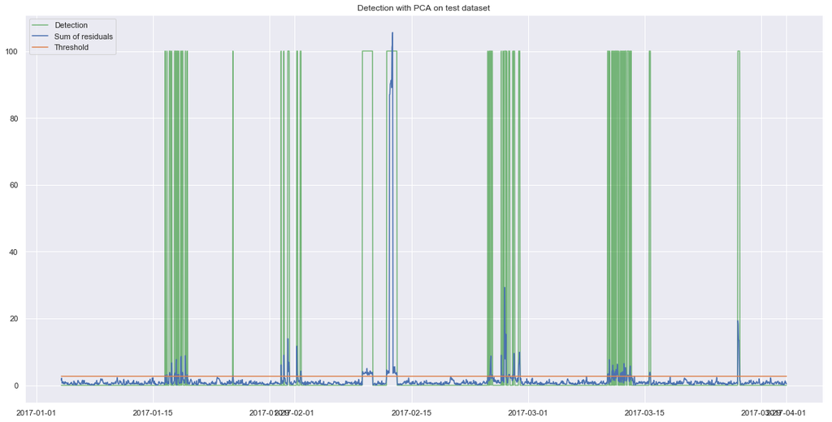

```python
# let's also compute what we would classify as attack.

detection = squared_sum_test_res > threshold_best
detection = detection.astype(int)

plt.figure(figsize=(20,10))
plt.plot(detection.map({0:0, 1:100}), color='green', alpha=0.5, label="Detection")
plt.plot(squared_sum_test_res, label='Sum of residuals')
plt.plot(threshold, label='Threshold')
plt.legend()

plt.title("Detection with PCA on test dataset")
plt.show()
```

By comparing with the image attached below (downloadable on the BATADAL website), it seems we are actually able to detect all of the attacks in the test set with PCA!

[figure not shown]